# Introduction to Biostatistics

# 1 Learning objectives

## 1.1 Learning objectives

- **Add predictors** to a linear regression model
- Interpret **partial regression coefficients**
- **Re-code predictors** to meet assumptions
- **Compare** different models using $R^2_{change}$

# 2 Adding predictors

## 2.1 Review: Linear regression

- Linear regression
  - **One** *continuous* outcome variable
  - **One or more** predictor variable

## 2.2 Bivariate regression

- **One predictor**, one outcome
  - **Slope** of line relating predictor and outcome
    - Expected change in $Y$ for 1 unit change in $X$
  - If predictor and outcome are **standardized**
    - Regression coefficient = correlation between $X$ and $Y$

## 2.3 Multiple regression

- With multiple predictors
  - **Correlations between predictors** affect regression coefficients
  - Not just how $X$ relates to $Y$
    - **How does $X$ relate to other predictors?**
- Interpretation changes
  - Subtle but important

## 2.4 Correlations and partial correlations

- “Correlation” (bivariate correlation)
  - **Ignore** the effect of other predictors
- Partial correlation
  - **“Control for”** or **“partial out”** the effect of other predictors
  - Other variables can be related to $X$, $Y$, or both

## 2.5 Three variables

Three variables that are all related to each other

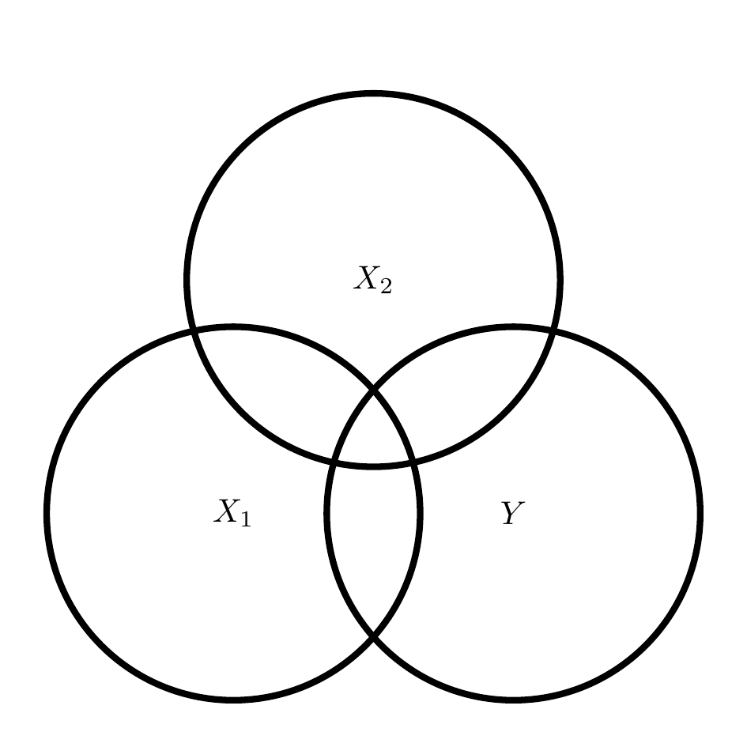

## 2.6 Bivariate correlation

Correlation between $X_1$ and $Y$, ignoring $X_2$

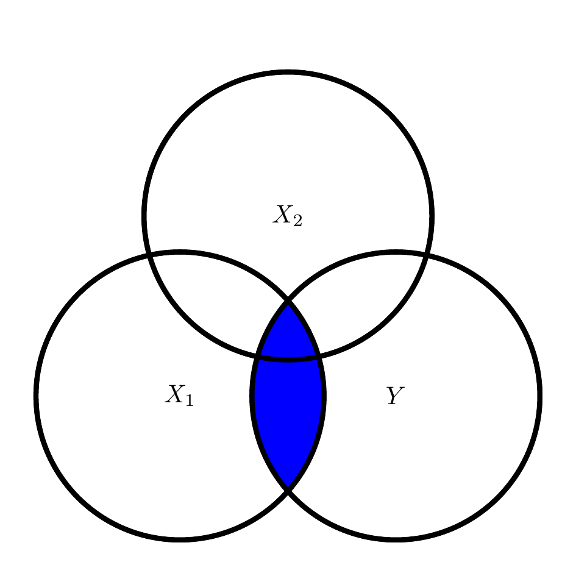

## 2.7 Partial correlation

Correlation between $X_1$ and $Y$, removing the effect of $X_2$

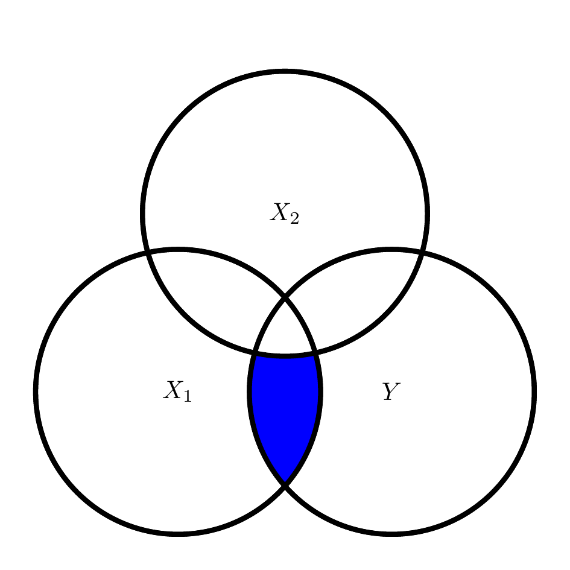

## 2.8 Uncorrelated predictors

Correlation between $X_1$ and $Y$, no effect of $X_2$

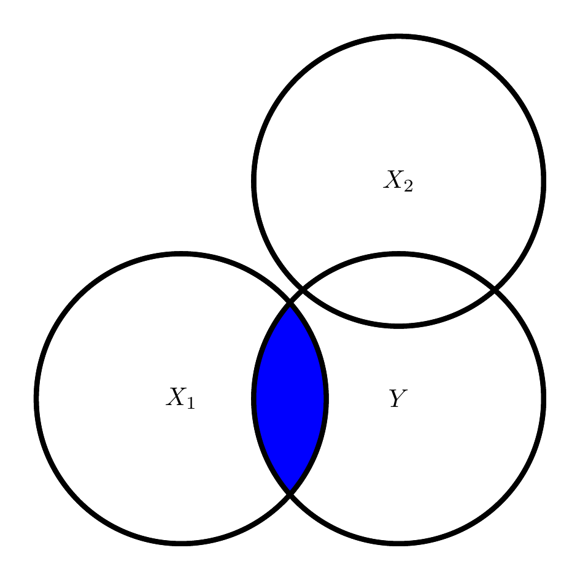

## 2.9 Example data

- `ICU` data from the **Stat2Data** package

```r
library(Stat2Data)
data(ICU)
head(ICU)
```

```
  ID Survive Age AgeGroup Sex Infection SysBP Pulse Emergency
1  4       0  87        3   1         1    80    96         1
2  8       1  27        1   1         1   142    88         1
3 12       1  59        2   0         0   112    80         1
4 14       1  77        3   0         0   100    70         0
5 27       0  76        3   1         1   128    90         1
6 28       1  54        2   0         1   142   103         1
```

## 2.10 Correlations between variables

```r
ICU_sub <- ICU[, c(3, 8, 9)]
cor(ICU_sub)
```

```
                  Age      Pulse  Emergency
Age        1.00000000 0.03736843 -0.1869571
Pulse      0.03736843 1.00000000  0.1752685
Emergency -0.18695714 0.17526851  1.0000000
```

## 2.11 Three models

- `Pulse ~ Age`

```r
pulse_vs_age <- lm(data = ICU,
                   Pulse ~ Age)
```

- `Pulse ~ Emergency`

```r
pulse_vs_ER <- lm(data = ICU,
                  Pulse ~ Emergency)
```

- `Pulse ~ Age + Emergency`

```r
pulse_vs_age_ER <- lm(data = ICU,
                      Pulse ~ Age + Emergency)
```

## 2.12 Compare models

```r
library(modelsummary)
modelsummary(list(pulse_vs_age, pulse_vs_ER, pulse_vs_age_ER))
```

|  | (1) | (2) | (3) |
| --- | --- | --- | --- |
| (Intercept) | 96.048 | 91.113 | 84.913 |
|  | (5.788) | (3.637) | (7.081) |
| Age | 0.050 |  | 0.097 |
|  | (0.095) |  | (0.095) |
| Emergency |  | 10.628 | 11.452 |
|  |  | (4.243) | (4.318) |
| Num.Obs. | 200 | 200 | 200 |
| R2 | 0.001 | 0.031 | 0.036 |
| R2 Adj. | -0.004 | 0.026 | 0.026 |
| AIC | 1888.1 | 1882.1 | 1883.1 |
| BIC | 1898.0 | 1892.0 | 1896.3 |
| Log.Lik. | -941.048 | -938.068 | -937.540 |
| F | 0.277 | 6.275 | 3.659 |
| RMSE | 26.74 | 26.35 | 26.28 |

## 2.13 Just the two predictor model

```r
summary(pulse_vs_age_ER)
```

```
Call:
lm(formula = Pulse ~ Age + Emergency, data = ICU)

Residuals:
   Min     1Q Median     3Q    Max
-63.10 -18.13  -3.56  17.27  88.73

Coefficients:
            Estimate Std. Error t value Pr(>|t|)
(Intercept) 84.91261    7.08132  11.991  < 2e-16 ***
Age          0.09723    0.09527   1.021  0.30873
Emergency   11.45223    4.31849   2.652  0.00866 **
---
Signif. codes:  0 '***' 0.001 '**' 0.01 '*' 0.05 '.' 0.1 ' ' 1

Residual standard error: 26.48 on 197 degrees of freedom
Multiple R-squared:  0.03582,   Adjusted R-squared:  0.02603
F-statistic: 3.659 on 2 and 197 DF,  p-value: 0.02753
```

## 2.14 Interpretation

- $\hat{Pulse} = 84.913 + 0.097 * Age + 11.452 * Emergency$
- The intercept ($b_0$) was 84.913, $t(1)$ = 11.991, $p$ < .0001. An individual who was *0 years old* **and** had a *non-emergency admission* is expected to have a pulse rate of 84.913.
  - $\hat{Pulse} = 84.913 + 0.097 * 0 + 11.452 * 0 = 84.913$

## 2.15 Interpretation

- The slope for age ($b_1$) was 0.097, $t(1)$ = 1.021, $p$ > .05. For each 1 year increase in age, the expected pulse rate increased by 0.097 points, **holding admission type constant**; this effect was not significant.
- The slope for admission type ($b_2$) was 11.452, $t(1)$ = 2.652, $p$ < .01. The difference in expected pulse rate between non-emergency admissions (0) and emergency admissions (1) was 11.452 points, **holding age constant**.

## 2.16 Interpretation

- The $R^2$ for this model was 0.036, F(2, 197) = 3.659, p < .05. About 3.6% of the variance in pulse rate was **explained by** *age* **and** *admission type*.
  - $F$-test for $R^2_{multiple}$ has two different degrees of freedom
  - Numerator df: # of predictors = 2
  - Denominator df: $N$ - # of predictors - 1 = 200 - 2 - 1 = 197

## 2.17 Two regression lines

- Simplify regression equation for each `Emergency` group
  - `Emergency` = 0
    - $\hat{Pulse} = 84.913 + 0.097 * Age + 11.452 * 0$
    - $\hat{Pulse} = 84.913 + 0.097 * Age$
  - `Emergency` = 1
    - $\hat{Pulse} = 84.913 + 0.097 * Age + 11.452 * 1$
    - $\hat{Pulse} = 96.365 + 0.097 * Age$

## 2.18 Two parallel lines

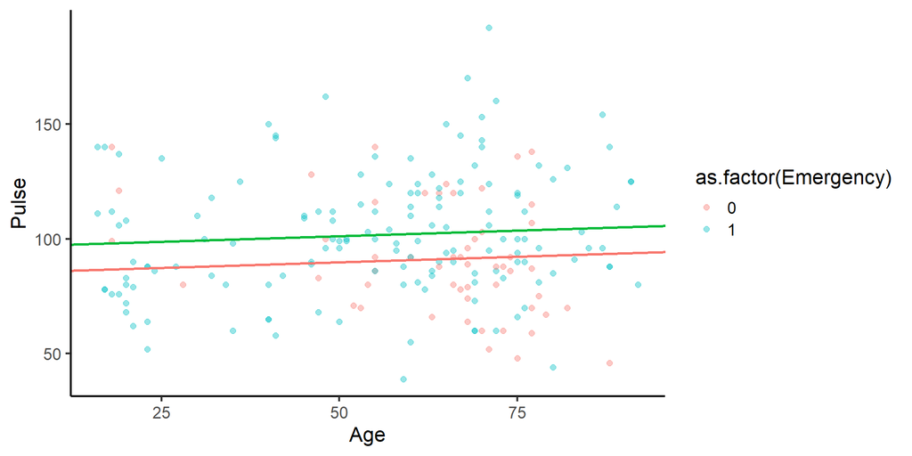

```r
ggplot(data = ICU,
       aes(x = Age,
           y = Pulse,
           color = as.factor(Emergency))) +
  geom_point(alpha = 0.4,
             size = 2) +
  geom_abline(intercept = 84.913,
              slope = 0.097,
              color="#F8766D",
              size = 1) +
  geom_abline(intercept = 96.365,
              slope = 0.097,
              color="#00BA38",
              size = 1)
```

- Same slope for each line: 0.097
- Same difference between lines at any `Age`: 11.452

## 2.19 Check assumptions

- With more than 1 predictor
  - Residual vs predictor 1
  - Residual vs predictor 2
  - Residual vs predicted outcome value (combination of predictor 1 and 2)

```r
ICU$pred <- fitted(pulse_vs_age_ER)
ICU$resi <- residuals(pulse_vs_age_ER)
```

## 2.20 Residual vs `Age`

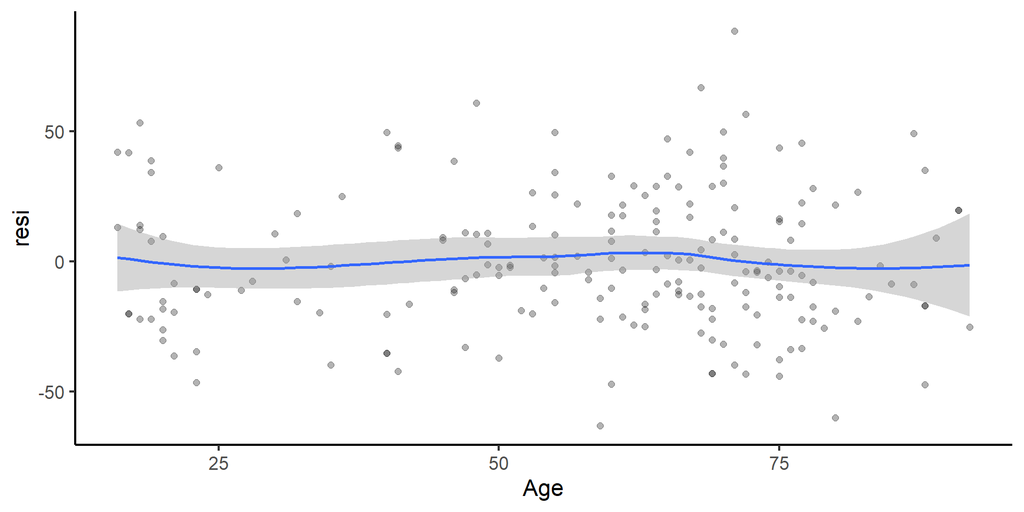

```r
ggplot(data = ICU,
       aes(x = Age, y = resi)) +
  geom_point(alpha = 0.3,
             size = 2) +
  geom_smooth()
```

## 2.21 Residual vs `Emergency`

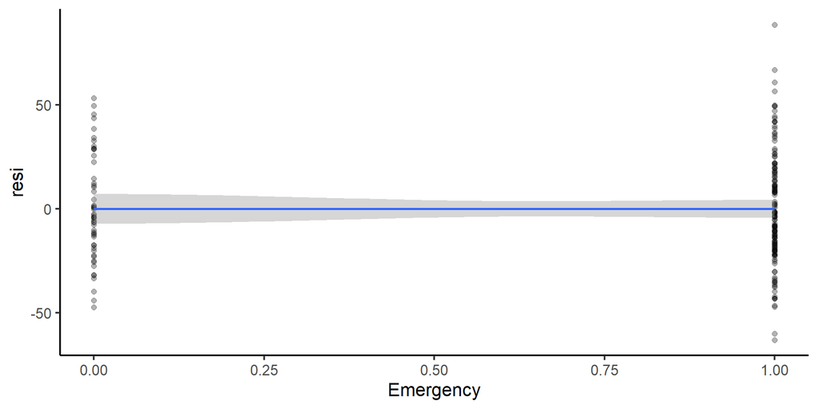

```r
ggplot(data = ICU,
       aes(x = Emergency, y = resi)) +
  geom_point(alpha = 0.3,
             size = 2) +
  geom_smooth()
```

## 2.22 Residual vs predicted `Pulse`

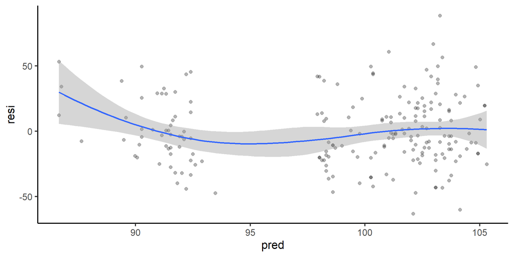

```r
ggplot(data = ICU,
       aes(x = pred, y = resi)) +
  geom_point(alpha = 0.3,
             size = 2) +
  geom_smooth()
```

## 2.23 Distribution of residuals

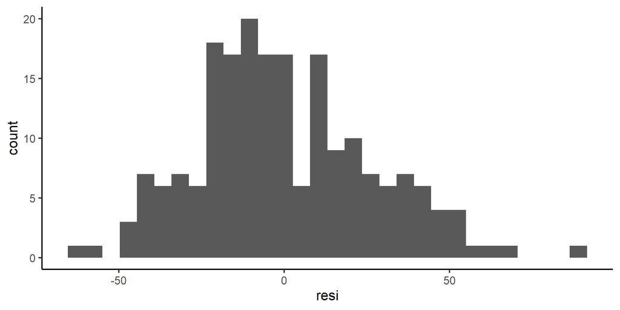

```r
ggplot(data = ICU,
       aes(x = resi)) +
  geom_histogram()
```

# 3 Coding predictors

## 3.1 Binary predictors

- Simplest coding scheme is 0,1
  - Intercept = expected outcome value for group coded zero
- Other options
  - 1,2 or -1,+1
  - Intercept is less interpretable

## 3.2 3 or more categories

- Dummy codes: Extension of 0,1 scheme to more categories
  - Also called “indicator variables”
- Note: 2 categories $\rightarrow$ 1 indicator variable
  - Always use $a - 1$ variables for $a$ categories

## 3.3 3 or more categories

- `AgeGroup` in the `ICU` data frame has **3 categories**
  - 1 = young (under 50)
  - 2 = middle (50-69)
  - 3 = old (70+)
- Create 3 indicator variables (dummy codes)
  - Value of 1 for a category, 0s for **all other** categories

## 3.4 3 or more categories

```r
ICU <- ICU %>% mutate(d1 = ifelse(AgeGroup == 1, 1, 0),
                      d2 = ifelse(AgeGroup == 2, 1, 0),
                      d3 = ifelse(AgeGroup == 3, 1, 0))

head(ICU)
```

```
  ID Survive Age AgeGroup Sex Infection SysBP Pulse Emergency      pred
1  4       0  87        3   1         1    80    96         1 104.82370
2  8       1  27        1   1         1   142    88         1  98.99000
3 12       1  59        2   0         0   112    80         1 102.10131
4 14       1  77        3   0         0   100    70         0  92.39919
5 27       0  76        3   1         1   128    90         1 103.75419
6 28       1  54        2   0         1   142   103         1 101.61517
        resi d1 d2 d3
1  -8.823701  0  0  1
2 -10.990001  1  0  0
3 -22.101308  0  1  0
4 -22.399190  0  0  1
5 -13.754189  0  0  1
6   1.384834  0  1  0
```

## 3.5 Analysis

- Select **any two** (in general, $a - 1$) dummy codes as predictors
  - The one that’s left out is the reference group (all 0s)
  - **All other groups are compared to the reference group**

| AgeGroup | d1 | d2 | d3 |
| --- | --- | --- | --- |
| 1 | 1 | 0 | 0 |
| 2 | 0 | 1 | 0 |
| 3 | 0 | 0 | 1 |

- Leave out `d3`: People in `AgeGroup` = 3 have 0s on both `d1` and `d2`

## 3.6 Analysis

```r
pulse_vs_agegroup <- lm(data = ICU, Pulse ~ d1 + d2)
summary(pulse_vs_agegroup)
```

```
Call:
lm(formula = Pulse ~ d1 + d2, data = ICU)

Residuals:
    Min      1Q  Median      3Q     Max
-60.429 -18.377  -3.429  19.781  92.641

Coefficients:
            Estimate Std. Error t value Pr(>|t|)
(Intercept)  99.3594     3.3694  29.489   <2e-16 ***
d1           -1.5628     4.8650  -0.321    0.748
d2            0.0692     4.5595   0.015    0.988
---
Signif. codes:  0 '***' 0.001 '**' 0.01 '*' 0.05 '.' 0.1 ' ' 1

Residual standard error: 26.96 on 197 degrees of freedom
Multiple R-squared:  0.000745,  Adjusted R-squared:  -0.0094
F-statistic: 0.07344 on 2 and 197 DF,  p-value: 0.9292
```

## 3.7 Interpretation

- **Intercept**: Expected `Pulse` for reference group (`AgeGroup` = 3)
- **Effect of `d1`**: Expected *difference* between the reference group (`AgeGroup` = 3) and the group coded 1 on `d1` (`AgeGroup` = 1)
- **Effect of `d2`**: Expected *difference* between the reference group (`AgeGroup` = 3) and the group coded 1 on `d2` (`AgeGroup` = 2)

## 3.8 Interpretation

- `Pulse` for `AgeGroup` = 3 is the **intercept**
  - 99.359
- `Pulse` for `AgeGroup` = 1 is 1.563 points **lower** (negative) than the value for `AgeGroup` = 3
  - 99.359 - 1.563 = 97.796
- `Pulse` for `AgeGroup` = 2 is 0.069 points **higher** (positive) than the value for `AgeGroup` = 3
  - 99.359 + 0.069 = 99.428

## 3.9 Interpretation: Figure

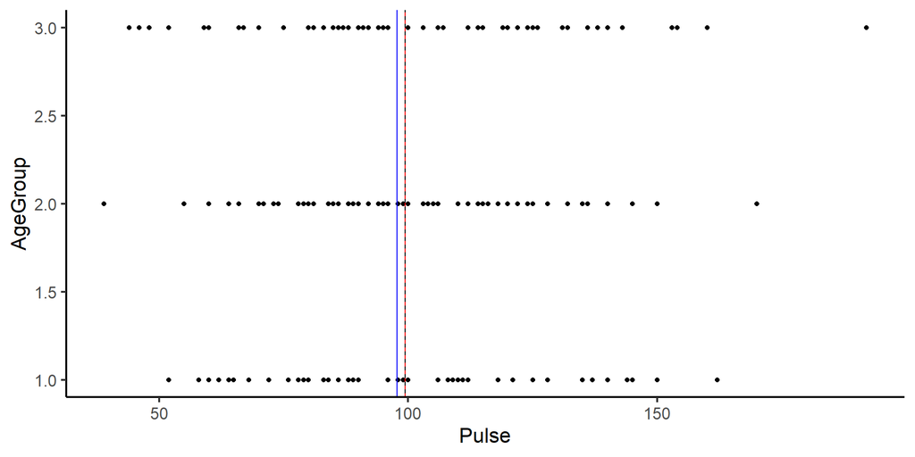

```r
ggplot(data = ICU,
       aes(x = AgeGroup, y = Pulse)) +
  geom_point() +
  geom_hline(yintercept = 99.359,
             color = "black") + #3
  geom_hline(yintercept = 97.796,
             color = "blue") + #1
  geom_hline(yintercept = 99.428,
             color = "red",
             linetype = "dashed") + #2
  coord_flip()
```

# 4 Centering predictors

## 4.1 What is an intercept?

- The **expected value** of the *outcome* when **all** predictors are *equal to 0*
  - (We just saw how this worked for dummy codes)
  - 0 may not exist for some predictors
  - 0 may be a non-meaningful value
- How can we make the 0 value more meaningful?

## 4.2 Centering predictors

- Move the 0 point to a new value
- Typically **mean centering**
  - But you can choose other (meaningful) values
  - Median, percentile, cut-off, etc.
- Subtract this value (e.g., mean) from all predictor values
- Mean of original variable = 0 in new variable
  - 0 is now a meaningful value, so the intercept is **interpretable**

## 4.3 Example: Mean center `Age`

```r
mean(ICU$Age, na.rm = TRUE)
```

```
[1] 57.545
```

```r
ICU$AgeC = ICU$Age - mean(ICU$Age, na.rm = TRUE)
head(ICU)
```

```
  ID Survive Age AgeGroup Sex Infection SysBP Pulse Emergency      pred
1  4       0  87        3   1         1    80    96         1 104.82370
2  8       1  27        1   1         1   142    88         1  98.99000
3 12       1  59        2   0         0   112    80         1 102.10131
4 14       1  77        3   0         0   100    70         0  92.39919
5 27       0  76        3   1         1   128    90         1 103.75419
6 28       1  54        2   0         1   142   103         1 101.61517
        resi d1 d2 d3    AgeC
1  -8.823701  0  0  1  29.455
2 -10.990001  1  0  0 -30.545
3 -22.101308  0  1  0   1.455
4 -22.399190  0  0  1  19.455
5 -13.754189  0  0  1  18.455
6   1.384834  0  1  0  -3.545
```

## 4.4 Model with centered predictor

```r
pulse_vs_ageC <- lm(data = ICU, Pulse ~ AgeC)
summary(pulse_vs_ageC)
```

```
Call:
lm(formula = Pulse ~ AgeC, data = ICU)

Residuals:
    Min      1Q  Median      3Q     Max
-59.998 -18.098  -4.123  19.452  92.402

Coefficients:
            Estimate Std. Error t value Pr(>|t|)
(Intercept) 98.92500    1.90060  52.049   <2e-16 ***
AgeC         0.04999    0.09501   0.526    0.599
---
Signif. codes:  0 '***' 0.001 '**' 0.01 '*' 0.05 '.' 0.1 ' ' 1

Residual standard error: 26.88 on 198 degrees of freedom
Multiple R-squared:  0.001396,  Adjusted R-squared:  -0.003647
F-statistic: 0.2769 on 1 and 198 DF,  p-value: 0.5993
```

## 4.5 Model with centered predictor

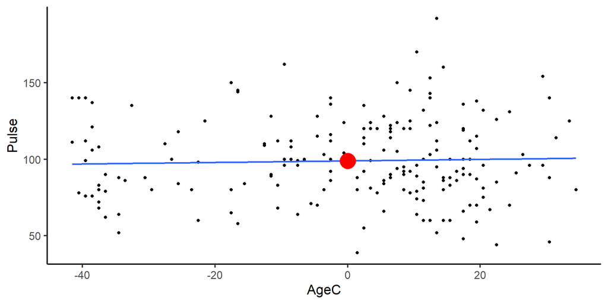

```r
ggplot(data = ICU,
       aes(x = AgeC, y = Pulse)) +
  geom_point() +
  geom_smooth(method = "lm",
              se = FALSE) +
  annotate("pointrange", x = 0,
           y = 98.925,
           ymin = 98.925,
           ymax = 98.925,
           colour = "red",
           size = 2)
```

- $b_0$ = 98.925: Predicted `Pulse` at **mean** `Age`

## 4.6 Other implications

- Centering predictors doesn’t change the **slopes**, only intercepts
- Centering predictors doesn’t change the $R^2_{multiple}$
- Interactions / moderation:
  - Conditional effects: Effect of one predictor **depends on** other predictors
  - Specifically, conditional on predictors being equal to 0
    - We’ll care where 0 is

# 5 Transforming predictors

## 5.1 “Linear in the predictors”

- $\hat{Y} = b_0 + b_1 X_1 + b_2 X_2 + \cdots$
  - Predicted value is a **linear combination** of *regression coefficients* and *predictors*
- In practice, this **looks like** a linear relationship between $X$ and $Y$
  - What if there’s not a straight line relationship?

## 5.2 Gapminder data

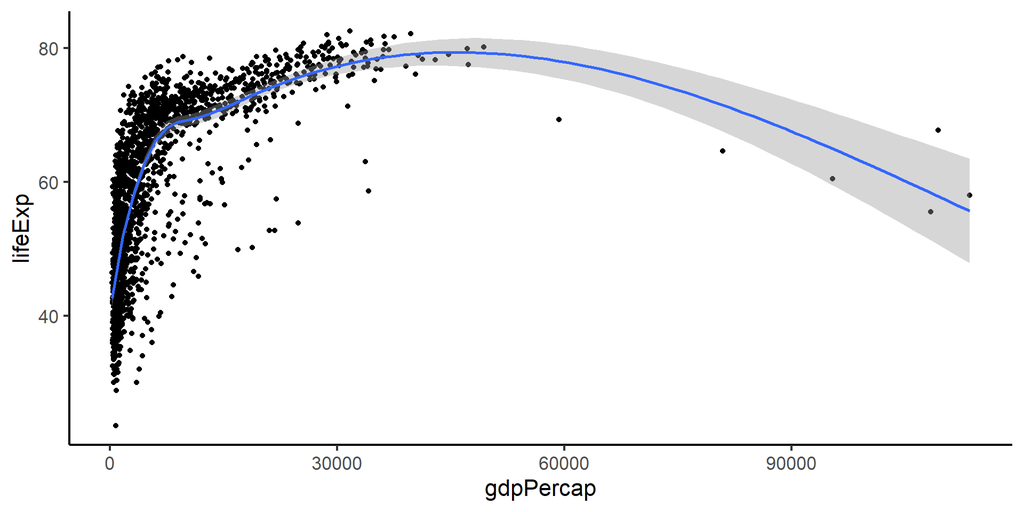

```r
library(gapminder)
data(gapminder)
ggplot(data = gapminder,
       aes(x = gdpPercap, y = lifeExp)) +
  geom_point() +
  geom_smooth()
```

## 5.3 Bad model

```r
bad_gdp <- lm(data = gapminder, lifeExp ~ gdpPercap)
gapminder$bad_pred <- fitted(bad_gdp)
gapminder$bad_resi <- residuals(bad_gdp)
summary(bad_gdp)
```

```
Call:
lm(formula = lifeExp ~ gdpPercap, data = gapminder)

Residuals:
    Min      1Q  Median      3Q     Max
-82.754  -7.758   2.176   8.225  18.426

Coefficients:
             Estimate Std. Error t value Pr(>|t|)
(Intercept) 5.396e+01  3.150e-01  171.29   <2e-16 ***
gdpPercap   7.649e-04  2.579e-05   29.66   <2e-16 ***
---
Signif. codes:  0 '***' 0.001 '**' 0.01 '*' 0.05 '.' 0.1 ' ' 1

Residual standard error: 10.49 on 1702 degrees of freedom
Multiple R-squared:  0.3407,    Adjusted R-squared:  0.3403
F-statistic: 879.6 on 1 and 1702 DF,  p-value: < 2.2e-16
```

## 5.4 Bad model: Fitted line

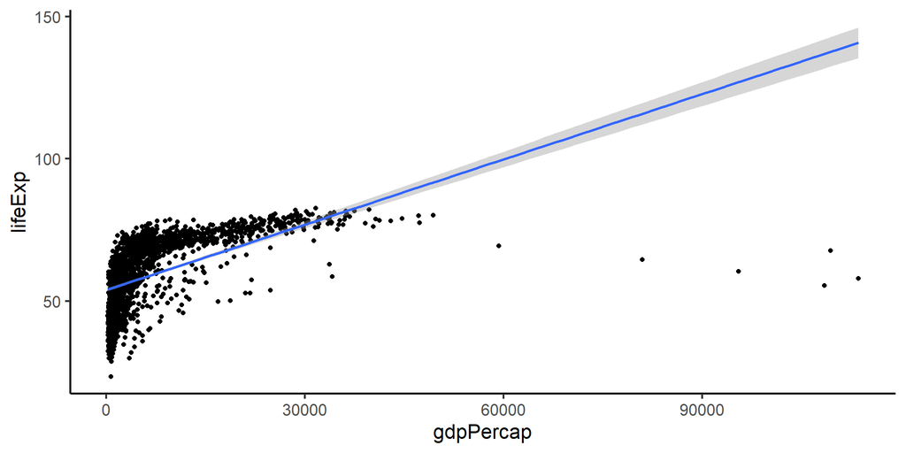

```r
ggplot(data = gapminder,
       aes(x = gdpPercap, y = lifeExp)) +
  geom_point() +
  geom_smooth(method = "lm")
```

## 5.5 Bad model: Residual vs predictor

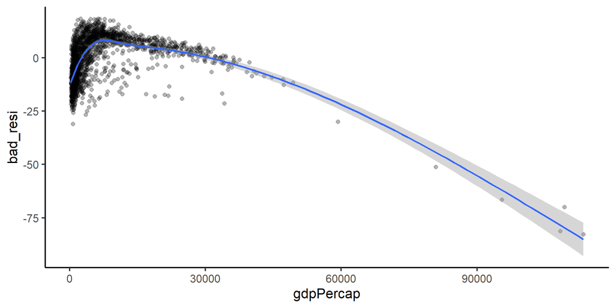

```r
ggplot(data = gapminder,
       aes(x = gdpPercap, y = bad_resi)) +
  geom_point(alpha = 0.3,
             size = 2) +
  geom_smooth()
```

## 5.6 Bad model: Residual distribution

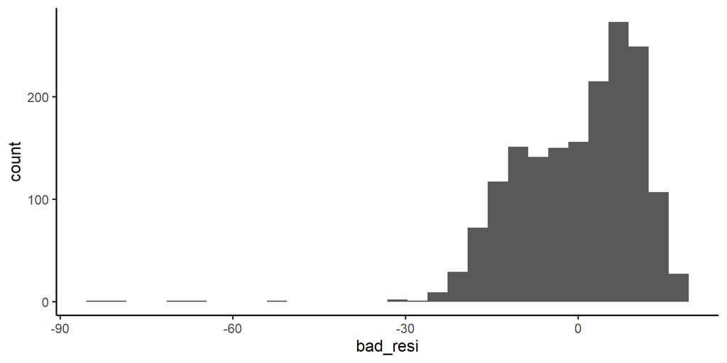

```r
ggplot(data = gapminder,
       aes(x = bad_resi)) +
  geom_histogram()
```

## 5.7 Transforming predictors

- It’s generally ok to transform **predictors** to make this work
  - Log transformation for very skewed predictors (e.g., GDP, income)
  - Add squared term ($X^2$) for curvilinear effects
- How do you know what transformation to use?
  - Literature
  - Plots
- Note: **Do not** transform outcomes

## 5.8 Example: Transform predictors

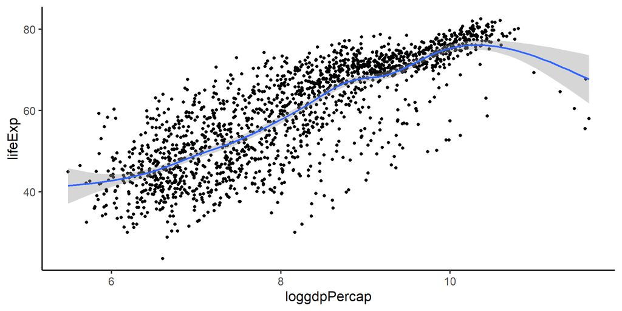

```r
gapminder <- gapminder %>% mutate(loggdpPercap = log(gdpPercap))
ggplot(data = gapminder,
       aes(x = loggdpPercap, y = lifeExp)) +
  geom_point() +
  geom_smooth()
```

## 5.9 Better model

```r
good_gdp <- lm(data = gapminder, lifeExp ~ loggdpPercap)
gapminder$good_pred <- fitted(good_gdp)
gapminder$good_resi <- residuals(good_gdp)
summary(good_gdp)
```

```
Call:
lm(formula = lifeExp ~ loggdpPercap, data = gapminder)

Residuals:
    Min      1Q  Median      3Q     Max
-32.778  -4.204   1.212   4.658  19.285

Coefficients:
             Estimate Std. Error t value Pr(>|t|)
(Intercept)   -9.1009     1.2277  -7.413 1.93e-13 ***
loggdpPercap   8.4051     0.1488  56.500  < 2e-16 ***
---
Signif. codes:  0 '***' 0.001 '**' 0.01 '*' 0.05 '.' 0.1 ' ' 1

Residual standard error: 7.62 on 1702 degrees of freedom
Multiple R-squared:  0.6522,    Adjusted R-squared:  0.652
F-statistic:  3192 on 1 and 1702 DF,  p-value: < 2.2e-16
```

## 5.10 Better model: Fitted line

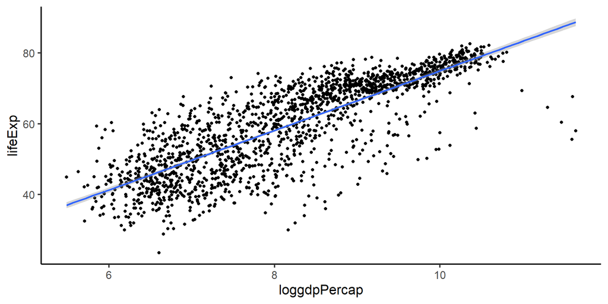

```r
ggplot(data = gapminder,
       aes(x = loggdpPercap, y = lifeExp)) +
  geom_point() +
  geom_smooth(method = "lm")
```

## 5.11 Better model: Residual vs predictor

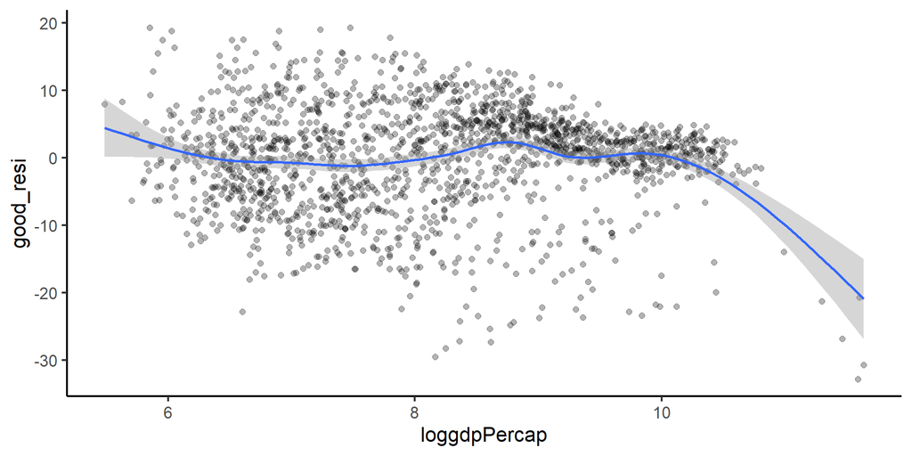

```r
ggplot(data = gapminder,
       aes(x = loggdpPercap, y = good_resi)) +
  geom_point(alpha = 0.3,
             size = 2) +
  geom_smooth()
```

## 5.12 Better model: Residual distribution

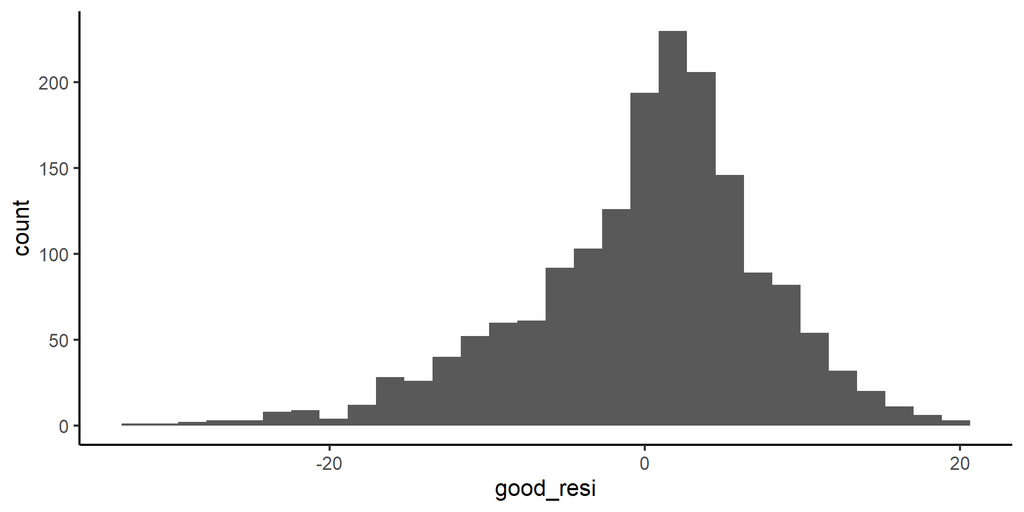

```r
ggplot(data = gapminder,
       aes(x = good_resi)) +
  geom_histogram()
```

# 6 Comparing models

## 6.1 Comparing models

```r
modelsummary(list(pulse_vs_age, pulse_vs_ER, pulse_vs_age_ER))
```

|  | (1) | (2) | (3) |
| --- | --- | --- | --- |
| (Intercept) | 96.048 | 91.113 | 84.913 |
|  | (5.788) | (3.637) | (7.081) |
| Age | 0.050 |  | 0.097 |
|  | (0.095) |  | (0.095) |
| Emergency |  | 10.628 | 11.452 |
|  |  | (4.243) | (4.318) |
| Num.Obs. | 200 | 200 | 200 |
| R2 | 0.001 | 0.031 | 0.036 |
| R2 Adj. | -0.004 | 0.026 | 0.026 |
| AIC | 1888.1 | 1882.1 | 1883.1 |
| BIC | 1898.0 | 1892.0 | 1896.3 |
| Log.Lik. | -941.048 | -938.068 | -937.540 |
| F | 0.277 | 6.275 | 3.659 |
| RMSE | 26.74 | 26.35 | 26.28 |

## 6.2 $R^2_{change}$

- Change in $R^2$ between models
  - Test whether that change is significant
  - Is more predictors worth a more complex model?
- Only for **nested models**
  - Same model, just add a new predictor
  - Can’t compare e.g., untransformed to transformed model

## 6.3 Test of $R^2_{change}$

```r
anova(pulse_vs_age, pulse_vs_age_ER)
```

```
Analysis of Variance Table

Model 1: Pulse ~ Age
Model 2: Pulse ~ Age + Emergency
  Res.Df    RSS Df Sum of Sq      F   Pr(>F)
1    198 143046
2    197 138115  1    4930.5 7.0326 0.008656 **
---
Signif. codes:  0 '***' 0.001 '**' 0.01 '*' 0.05 '.' 0.1 ' ' 1
```

- This test is **significant**, so
  - **Yes**, adding `Emergency` to a model with `Age` significantly increases the $R^2$ for the model from .001 to .036; F(1, 197) = 7.0326, p<.01

## 6.4 Test of $R^2_{change}$

```r
anova(pulse_vs_ER, pulse_vs_age_ER)
```

```
Analysis of Variance Table

Model 1: Pulse ~ Emergency
Model 2: Pulse ~ Age + Emergency
  Res.Df    RSS Df Sum of Sq      F Pr(>F)
1    198 138845
2    197 138115  1    730.16 1.0415 0.3087
```

- This test is **not significant**, so
  - **No**, adding `Age` to a model with `Emergency` does not significantly increase the $R^2$ for the model from .031 to .036; F(1, 197) = 1.0415, p>.05

## 6.5 AIC and BIC

- Use AIC or BIC to compare **non-nested models**
  - No statistical test: **Smaller is better**
  - Penalizes more complex models (i.e., more predictors)
- `AIC()` or `BIC()` functions from **stats** package (always loads)

```r
AIC(pulse_vs_age)
```

```
[1] 1888.096
```

```r
AIC(pulse_vs_ER)
```

```
[1] 1882.135
```

```r
AIC(pulse_vs_age_ER)
```

```
[1] 1883.081
```

## 6.6 AIC for transformed models

```r
AIC(bad_gdp)
```

```
[1] 12850.41
```

```r
AIC(good_gdp)
```

```
[1] 11760.42
```

```r
BIC(bad_gdp)
```

```
[1] 12866.73
```

```r
BIC(good_gdp)
```

```
[1] 11776.74
```

# 7 Next time

## 7.1 Expanding the model (more)

- Hypothesis testing
- More checking assumptions: Residuals and outliers
- Estimation of the model
  - $R^2$, likelihood
- Interaction (moderator) effects